# Suicide Rates Overview 1985 to 2016

## by Aisulu Omar

## Investigation Overview

The goal of this presentation is to show key points of the history of suicide rates from 1985 to 2016.

## Dataset Overview

This compiled dataset pulled from four other datasets linked by time and place, and was built to find signals correlated to increased suicide rates among different cohorts globally, across the socio-economic spectrum.

United Nations Development Program. (2018). Human development index (HDI). Retrieved from http://hdr.undp.org/en/indicators/137506

World Bank. (2018). World development indicators: GDP (current US$) by country:1985 to 2016. Retrieved from http://databank.worldbank.org/data/source/world-development-indicators#

[Szamil]. (2017). Suicide in the Twenty-First Century [dataset]. Retrieved from https://www.kaggle.com/szamil/suicide-in-the-twenty-first-century/notebook

World Health Organization. (2018). Suicide prevention. Retrieved from http://www.who.int/mental_health/suicide-prevention/en/

### Inspiration

Suicide Prevention.

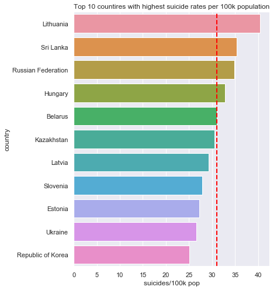

```python
sns.set(style="darkgrid")
colors = ["amber", "windows blue", "greyish", "faded green", "dusty purple"]
sns.set_palette(sns.xkcd_palette(colors))
byCountry = df.groupby('country').mean().sort_values('suicides/100k pop', ascending=False).reset_index()[:11]
plt.figure(figsize=(6,8))
sns.barplot(x='suicides/100k pop',y='country',data=byCountry)
plt.axvline(x= byCountry['suicides/100k pop'].mean(),color='red',ls='--',linewidth=2)
plt.title('Top 10 countires with highest suicide rates per 100k population');
```

#### Findings:

- I am surprised that country of my origin (Kazakhstan) is on the 6th place.
- Luthania has the highest suicide rate per 100k population.
- 7 out of 10 countires in this list were part of USSR.

### 10 countires with the lowest rate of suicides per 100k popilation

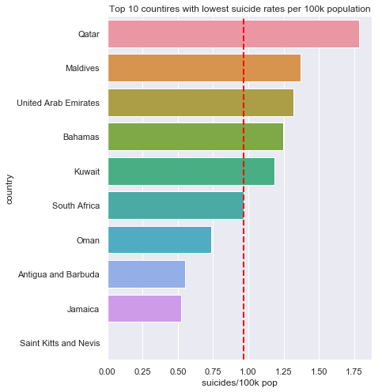

```python
byCountry = df.groupby('country').mean().sort_values('suicides/100k pop', ascending=False).reset_index()[-11:-1]
plt.figure(figsize=(6,8))
sns.barplot(x='suicides/100k pop',y='country',data=byCountry)
plt.axvline(x= byCountry['suicides/100k pop'].mean(),color='red',ls='--',linewidth=2)
plt.title('Top 10 countires with lowest suicide rates per 100k population');
```

## Number of suicides from 1985 to 2015 by different categories

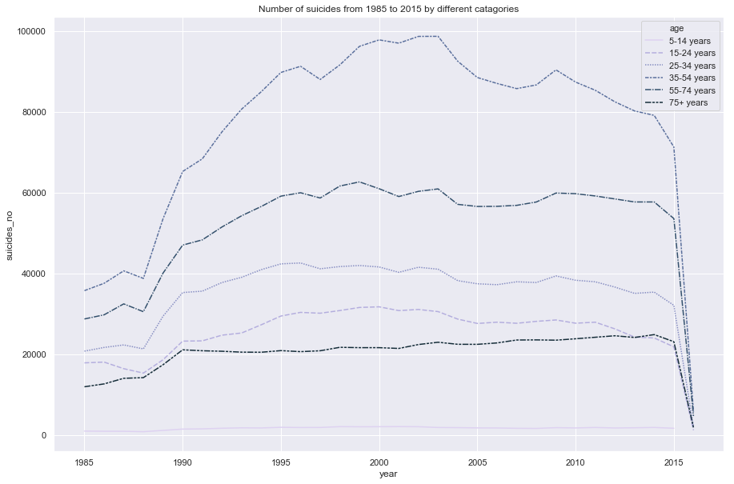

```python
from matplotlib.colors import LogNorm

df_n = df.groupby(['year','age']).suicides_no.sum().reset_index()
df_n['age'] = df_n.age.astype(pd.api.types.CategoricalDtype(categories = ['5-14 years','15-24 years','25-34 years','35-54 years','55-74 years','75+ years']))
sns.set(rc={'figure.figsize':(15,10)})
sns.lineplot('year','suicides_no',hue='age',style='age',data=df_n,hue_norm=LogNorm(),palette='ch:2.5,.25',sort=False)
plt.title('Number of suicides from 1985 to 2015 by different catagories');
```

## The growth of the number of suicides between different age groups

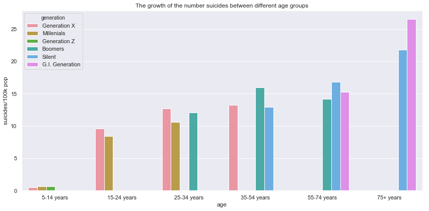

```python
plt.figure(figsize=(12,6))

byAgeGen = df.groupby(['age','generation']).mean().sort_values('suicides/100k pop',ascending=True).reset_index()
sns.barplot(x='age',y='suicides/100k pop',data=byAgeGen, hue='generation')
plt.title('The growth of the number suicides between different age groups')
plt.tight_layout();
```